# Creating a color palette from an image

Summaries

Eukaryota

Plantae

Martin Westgate  
March 2021

#### Author:

[Martin Westgate](https://labs.ala.org.au/people/Westgate_Martin/index.html)

#### Date:

March 2021

# Colors in R

Color palettes are important to people, and the R ecosystem includes literally hundreds of possible palettes. If you want a “complete” list, go and check out Emil Hvitfeldt’s list of palettes [here](https://github.com/EmilHvitfeldt/r-color-palettes); but in practice there are only a few that we use routinely. Our default at ALA labs is to use `viridis` for continuous scales, because (to quote their [CRAN page](https://cran.r-project.org/web/packages/viridis/vignettes/intro-to-viridis.html)) it’s color-blind friendly, perceptually uniform, and pretty. The default purple-green-yellow color scheme is lovely, but I’m a big fan of ‘magma’, which has a black-purple-orange-yellow scheme

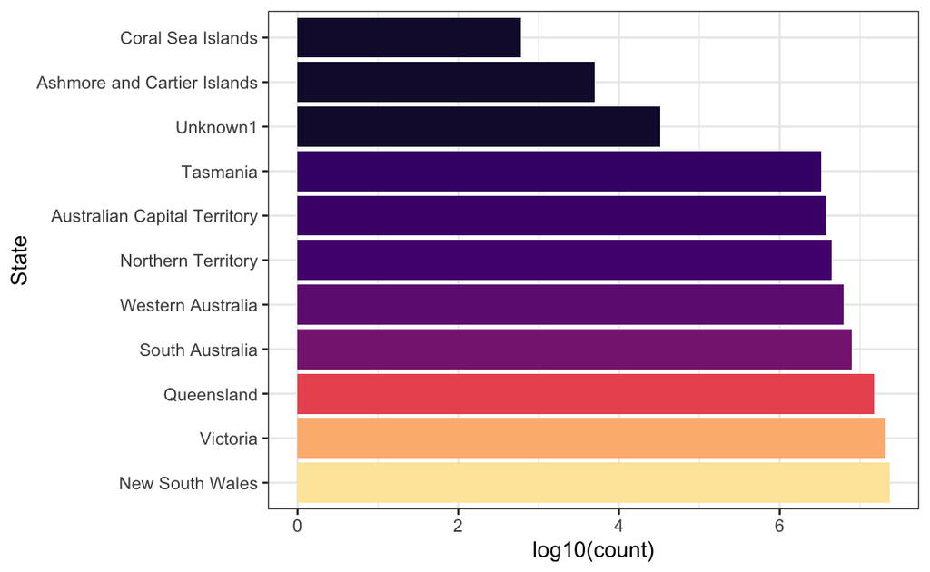

```r
library(galah)
library(ggplot2)
library(viridis)

records <- ala_counts(group_by = "cl22")
records$State <- factor(seq_len(nrow(records)), labels = records$cl22)

ggplot(records, aes(x = State, y = log10(count), fill = count)) +
  geom_bar(stat = "identity") +
  coord_flip() +
  scale_fill_viridis(option = "magma", begin = 0.10, end = 0.95) +
  theme_bw() +
  theme(legend.position = "none")
```

My default for categorical color schemes is the ‘dark2’ palette from `RColorBrewer`; but given the subject matter of our work, it’s worth mentioning the wonderful `feather` package by Shandiya Balasubramaniam, which gives colors based on Australian bird plumage

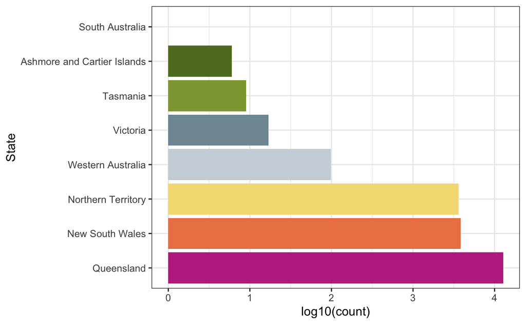

```r
# remotes::install_github(repo = "shandiya/feathers")
library(feathers)

rcfd <- ala_counts(
  taxa = select_taxa("Rose-crowned Fruit-Dove"),
  group_by = "cl22")
rcfd$State <- factor(seq_len(nrow(rcfd)), labels = rcfd$cl22)

ggplot(rcfd, aes(x = State, y = log10(count), fill = State)) +
  geom_bar(stat = "identity") +
  coord_flip() +
  scale_fill_manual(values = get_pal("rose_crowned_fruit_dove")) +
  theme_bw() +
  theme(legend.position = "none")
```

All of this is fine, but what if you have a specific image that you want to take colors from? A logical choice is to pick the colors you want using an image editting program, but if we want to try something automated, there are options in R as well.

# Extracting colors

[National Eucalypt Day](https://www.eucalyptaustralia.org.au/national-eucalypt-day/national-eucalypt-day/) aims to raise awareness about Eucalypts and celebrate their influence on the lives of Australians. In honour of National Eucalypt day, we wanted to created a plot based on occurrences data held in the Atlas of Living Australia, themed using colours from actual Eucalypts.

We used this image from a tweet by Dean Nicolle:

> Happy 'National Eucalypt Day'!  
> The Western Australian gimlet (Eucalyptus salubris) has just been announced as Eucalypt of the Year for 2021. Renowned for its fluted, smooth, shiny, and colourful trunk & branches. [pic.twitter.com/pOsufQtxWS](https://t.co/pOsufQtxWS)

> — Dean Nicolle (@DeanNicolle1) [March 22, 2021](https://twitter.com/DeanNicolle1/status/1374112431782301698?ref_src=twsrc%5Etfw)

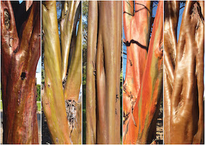

Image of Eucalyptus salubris by Dean Nicolle

First, get observations of the Eucalypt of the Year 2021 from ALA using the [galah](https://atlasoflivingaustralia.github.io/galah/index.html) package. Specifically, we use `ala_counts()` to determine how many records of *Eucalyptus salubris* are held by the ALA:

```r
n_records <- ala_counts(taxa = select_taxa("Eucalyptus salubris"))
```

Then get a color scheme from images of the species in question using the paletter package (which needs to be installed from GitHub)

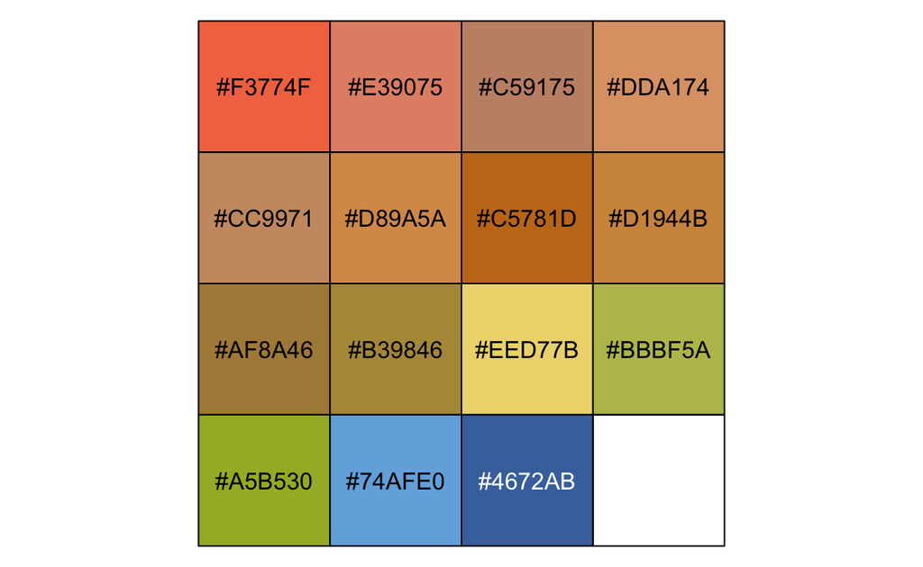

```r
# remotes::install_github("AndreaCirilloAC/paletter")
library(paletter)

image_pal <- create_palette(
  image_path = "./data/Dean_Nicolle_Esalubris_image_small.jpeg",
  type_of_variable = "categorical",
  number_of_colors = 15)
```

Note that we downsized the image before running the `paletter` code, as large images take much longer to process.

# Creating a plot

Once we have this palette, the obvious question is what kind of plot to draw. We could have done a map, but those can be a bit boring. We decided to try something that represented the number of observations we had of this species at ALA, and included color, but was otherwise just a pretty picture that didn’t need to contain any further information. Rather than have a traditional x and y axis, therefore, we decided to try out the [igraph](https://igraph.org/r/) package to plot the points in an interesting way.

First, we create a vector containing as many points as we want to display, and distribute our colors among them as evenly as possible

```r
# create a vector to index colours
colour_index <- rep(seq_along(image_pal),
  each = floor(n_records / length(image_pal)))
# correct rounding errors
colour_index <- c(colour_index,
  rep(length(image_pal), n_records - length(colour_index)))
```

Then we can create a network using `igraph`, and use it to create a layout for our points

```r
library(igraph)

graph_list <- lapply(c(1:15), function(a){
  lookup <- which(colour_index == a)
  return(data.frame(
    from = lookup[c(1:(length(lookup)-1))],
    to = lookup[c(2:length(lookup))]))
  })
graph_df <- as.matrix(do.call(rbind, graph_list))         # build matrix
colour_graph <- graph_from_edgelist(graph_df)             # create network graph

# convert to a set of point locations
test_layout <- as.data.frame(layout_nicely(colour_graph)) # convert to df
colnames(test_layout) <- c("x", "y")                      # change colnames
test_layout$colour_index <- factor(colour_index)          # add colour_index col
```

Finally, we draw the plot with [ggplot2](https://ggplot2.tidyverse.org/), removing axes with `theme_void()`

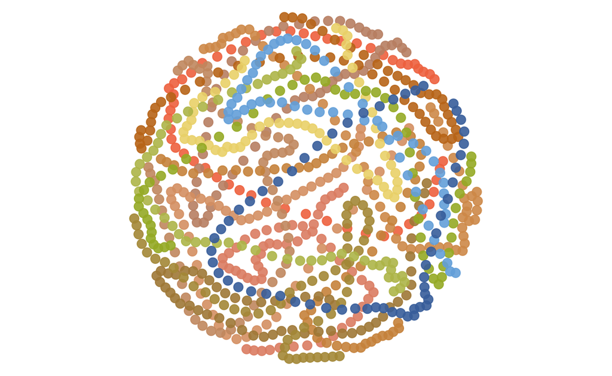

```r
ggplot(test_layout, aes(x = x, y = y, colour = colour_index)) +
  geom_point(size = 3, alpha = 0.9) +
  scale_color_manual(values = image_pal) +
  coord_fixed() +
  theme_void() +
  theme(legend.position = "none")
```

That’s it! While I like the effect here, I think the `paletter` package is best suited to cases where there are large areas of strongly contrasting colors; it’s less ideal for images with subtle color differences. It also doesn’t appear to have been updated lately, which may mean it’s not being supported any more. But I’m happy with this plot, and would definitely consider using it again.